# Improving R Perfomance by installing optimized BLAS/LAPACK libraries

July 25th, 2018

Carlos Santillan

Principal Software Engineer

Bentley Systems Inc.

https://www.linkedin.com/in/carlos-santillan/

csantill@gmail.com

https://github.com/csantill/RPerformanceWBLAS

The precompiled R distribution that is downloaded from CRAN makes use of the reference BLAS/LAPACK implementation for linear algebra operations, These implementations are built to be stable and cross platform compatible but are not optimized for performance. We will review the steps to install highly optimized libraries and benchmark their performance.

# Base Libraries

## BLAS

The BLAS (Basic Linear Algebra Subprograms) are routines that provide standard building blocks for performing basic vector and matrix operations. The Level 1 BLAS perform scalar, vector and vector-vector operations, the Level 2 BLAS perform matrix-vector operations, and the Level 3 BLAS perform matrix-matrix operations. Because the BLAS are efficient, portable, and widely available, they are commonly used in the development of high quality linear algebra software

## LAPACK

LAPACK is written in Fortran 90 and provides routines for solving systems of simultaneous linear equations, least-squares solutions of linear systems of equations, eigenvalue problems, and singular value problems. The associated matrix factorizations (LU, Cholesky, QR, SVD, Schur, generalized Schur) are also provided, as are related computations such as reordering of the Schur factorizations and estimating condition numbers. Dense and banded matrices are handled, but not general sparse matrices. In all areas, similar functionality is provided for real and complex matrices, in both single and double precision.

[session information not shown]

Here is the output when using the default BLAS/LAPACK libraries

```
## BLAS: /usr/lib/x86_64-linux-gnu/blas/libblas.so.3.7.1
## LAPACK: /usr/lib/x86_64-linux-gnu/lapack/liblapack.so.3.7.1
```

[session information not shown]

# Alternative libraries

## OpenBLAS

OpenBLAS is an optimized BLAS library based on GotoBLAS2 1.13 BSD version

## AtlasBLAS

The ATLAS (Automatically Tuned Linear Algebra Software) project is an ongoing research effort focusing on applying empirical techniques in order to provide portable performance.

# GotoBLAS

GotoBLAS and GotoBLAS2 are open source implementations of the BLAS (Basic Linear Algebra Subprograms) API with many hand-crafted optimizations for specific processor types. GotoBLAS was developed by Kazushige Goto at the Texas Advanced Computing Center (UT). As of 2003, it was used in seven of the world’s ten fastest supercomputers.

## Intel MKL

Intel Math Kernel Library

Features highly optimized, threaded, and vectorized math functions that maximize performance on each processor family Uses industry-standard C and Fortran APIs for compatibility with popular BLAS, LAPACK, and FFTW functions—no code changes required

The Intel MKL used to a commercial product, free for student use, paid license for other uses, it looks like it is now free

*Free for all, no royalties, no restrictions on company or project size, access to current & older versions of libraries (only current version for Intel® MPI), Forum Support.*

The above mentioned libraries are optimized for perfomance and are used in production.

GotoBLAS at one time ran on 7 of the top 10 supercomputers in the world, ATLASBLAS is used for Matlab (for some platforms), Matlab uses Veclib on Mac.

## Installing the libraries

The following steps have been tested on Ubuntu 18.04 “Bionic Beaver”, but they should work on debian distributions. We can use apt-cache search to see what libblas debian packages are available to install

```
apt-cache search libblas
```

```
csantill@gawain:/usr/bin$ apt-cache search libblas
libblas-dev - Basic Linear Algebra Subroutines 3, static library
libblas3 - Basic Linear Algebra Reference implementations, shared library
libatlas-base-dev - Automatically Tuned Linear Algebra Software, generic static
libatlas3-base - Automatically Tuned Linear Algebra Software, generic shared
libblas-test - Basic Linear Algebra Subroutines 3, testing programs
libblasr - tools for aligning PacBio reads to target sequences
libblasr-dev - tools for aligning PacBio reads to target sequences (development files)
libopenblas-base - Optimized BLAS (linear algebra) library (shared library)
libopenblas-dev - Optimized BLAS (linear algebra) library (development files)
```

Install OpenBLAS and AtlasBLAS wit the following command

```
$ sudo apt-get install libopenblas-base libatlas3-base
```

## Installing the Intel MKL

The following script form [“Adding Intel MKL easily via a simple script”](http://dirk.eddelbuettel.com/blog/2018/04/15/) provides a simple way to install the Intel MKL

```
sudo script.sh
```

```
#!/bin/bash
##
## cf https://software.intel.com/en-us/articles/installing-intel-free-libs-and-python-apt-repo

cd /tmp
wget https://apt.repos.intel.com/intel-gpg-keys/GPG-PUB-KEY-INTEL-SW-PRODUCTS-2019.PUB
apt-key add GPG-PUB-KEY-INTEL-SW-PRODUCTS-2019.PUB

## all products:
#sudo wget https://apt.repos.intel.com/setup/intelproducts.list -O /etc/apt/sources.list.d/intelproducts.list
## just MKL
sh -c 'echo deb https://apt.repos.intel.com/mkl all main > /etc/apt/sources.list.d/intel-mkl.list'
## other (TBB, DAAL, MPI, ...) listed on page

apt-get update
apt-get install intel-mkl-64bit-2018.2-046   ## wants 500+mb :-/  installs to 1.8 gb :-/

## update alternatives
update-alternatives --install /usr/lib/x86_64-linux-gnu/libblas.so     libblas.so-x86_64-linux-gnu      /opt/intel/mkl/lib/intel64/libmkl_rt.so 50
update-alternatives --install /usr/lib/x86_64-linux-gnu/libblas.so.3   libblas.so.3-x86_64-linux-gnu    /opt/intel/mkl/lib/intel64/libmkl_rt.so 50
update-alternatives --install /usr/lib/x86_64-linux-gnu/liblapack.so   liblapack.so-x86_64-linux-gnu    /opt/intel/mkl/lib/intel64/libmkl_rt.so 50
update-alternatives --install /usr/lib/x86_64-linux-gnu/liblapack.so.3 liblapack.so.3-x86_64-linux-gnu  /opt/intel/mkl/lib/intel64/libmkl_rt.so 50

echo "/opt/intel/lib/intel64"     >  /etc/ld.so.conf.d/mkl.conf
echo "/opt/intel/mkl/lib/intel64" >> /etc/ld.so.conf.d/mkl.conf
ldconfig

echo "MKL_THREADING_LAYER=GNU" >> /etc/environment
```

# Microsoft R Open

R Open (formerly Revolution R Open) is an enhanced distribution of R.

The current version, Microsoft R Open 3.5.0, is based on (and 100% compatible with) R-3.5.0, has full compatibility with all packages, scripts and applications that work with R. It includes additional capabilities for improved performance, reproducibility, and support for Windows, Linux-based and OS X platforms.

(Windows and Linux version use Intel MKL libraries, OS X uses Accelerate ML)

https://mran.microsoft.com/open

# Selecting the default BLAS/LAPACK

Once you have installed the different BLAS/LAPACK libraries you can use update alternatives to select the default library

Note: You will have to to restart R/R Studio for the change to take effect, you can use sessionInfo() to confirm that you are using the library you want

## Change default BLAS

Run update-alternatives to select one of the installed Alternatives

```
sudo update-alternatives --config libblas.so.3-x86_64-linux-gnu
```

```
csantill@gawain:~$ sudo update-alternatives --config libblas.so.3-x86_64-linux-gnu
There are 4 choices for the alternative libblas.so.3-x86_64-linux-gnu (providing /usr/lib/x86_64-linux-gnu/libblas.so.3).

  Selection    Path                                             Priority   Status
------------------------------------------------------------
  0            /opt/intel/mkl/lib/intel64/libmkl_rt.so           50        auto mode
* 1            /opt/intel/mkl/lib/intel64/libmkl_rt.so           50        manual mode
  2            /usr/lib/x86_64-linux-gnu/atlas/libblas.so.3      35        manual mode
  3            /usr/lib/x86_64-linux-gnu/blas/libblas.so.3       10        manual mode
  4            /usr/lib/x86_64-linux-gnu/openblas/libblas.so.3   40        manual mode

Press <enter> to keep the current choice[*], or type selection number:
```

## Change default LAPACK

```
sudo update-alternatives --config liblapack.so.3-x86_64-linux-gnu
```

```
csantill@gawain:~$ sudo update-alternatives --config liblapack.so.3-x86_64-linux-gnu
There are 4 choices for the alternative liblapack.so.3-x86_64-linux-gnu (providing /usr/lib/x86_64-linux-gnu/liblapack.so.3).

  Selection    Path                                               Priority   Status
------------------------------------------------------------
  0            /opt/intel/mkl/lib/intel64/libmkl_rt.so             50        auto mode
* 1            /opt/intel/mkl/lib/intel64/libmkl_rt.so             50        manual mode
  2            /usr/lib/x86_64-linux-gnu/atlas/liblapack.so.3      35        manual mode
  3            /usr/lib/x86_64-linux-gnu/lapack/liblapack.so.3     10        manual mode
  4            /usr/lib/x86_64-linux-gnu/openblas/liblapack.so.3   40        manual mode

Press <enter> to keep the current choice[*], or type selection number:
```

# BenchMarks

I ran the R Benchmark 2.5 scripts under each of the configurations. The accompanying article [Why is R slow? some explanations and MKL/OpenBLAS setup to try to fix this](https://www.r-bloggers.com/why-is-r-slow-some-explanations-and-mklopenblas-setup-to-try-to-fix-this/) was one of the references I used.

The script I used can be found

https://github.com/pachamaltese/r-with-intel-mkl/blob/master/00-benchmark-scripts/1-r-benchmark-25.R

And can be run from

```
source("1-r-benchmark-25.R")
```

As can be seen from the Benchmark results OpenBLAS is about 2.85 times faster than the default BLAS and MKL is about 3.25 times faster, also AtlasBLAS is about twice as fast as the default. With some operations such as Matrix Cross Product being over 20 times faster.

```
   R Benchmark 2.5
   ===============
Number of times each test is run__________________________:  3
                                                          BLAS  OpenBLAS    MKL   ATLASBLAS

A) Creation, transp., deformation of a 2500x2500 matrix :       1.424     1.411   1.611     1.371
B) 2400x2400 normal distributed random matrix ^1000____ :       1.028     1.030   1.030     1.024
C) Sorting of 7,000,000 random values__________________ :       1.423     1.433   1.346     1.441
D) 2800x2800 cross-product matrix (b = a' * a)_________ :      20.687     0.789   0.577     3.756
E) Linear regr. over a 3000x3000 matrix (c = a \ b')___ :       9.898     0.561   0.322     1.939
```

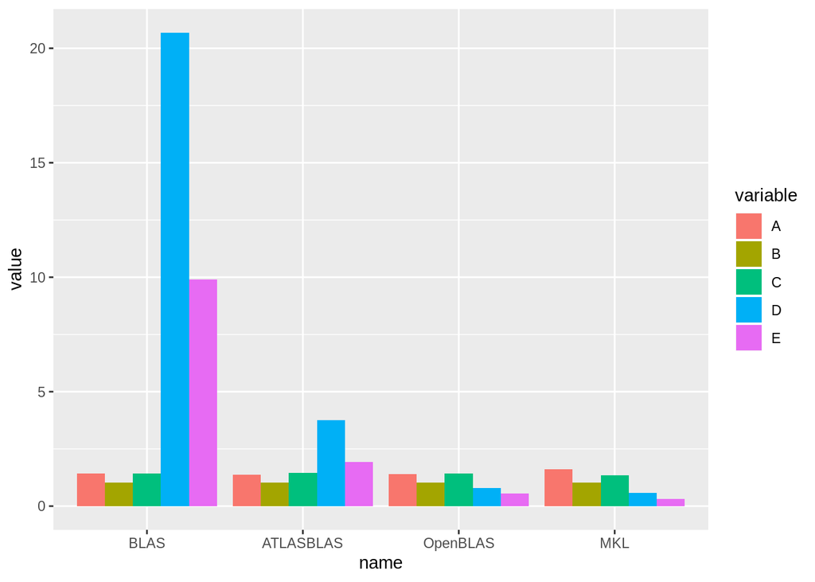

```
Trimmed geom. mean (2 extremes eliminated)                  2.717     1.047   0.928     1.565

F) FFT over 2,400,000 random values____________________ :       0.575     0.535   0.570     0.534
G) Eigenvalues of a 640x640 random matrix______________ :       1.470     1.028   0.480     0.921
H) Determinant of a 2500x2500 random matrix____________ :       6.727     0.456   0.322     1.873
I) Cholesky decomposition of a 3000x3000 matrix________ :       8.314     0.444   0.321     1.617
J) Inverse of a 1600x1600 random matrix________________ :       6.069     0.493   0.296     1.603

Trimmed geom. mean (2 extremes eliminated)           :      3.915   0.494     0.368     1.336
```

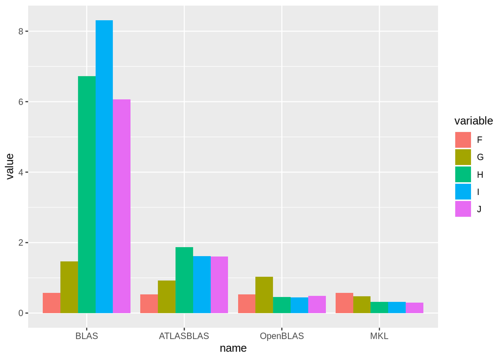

[output not shown]

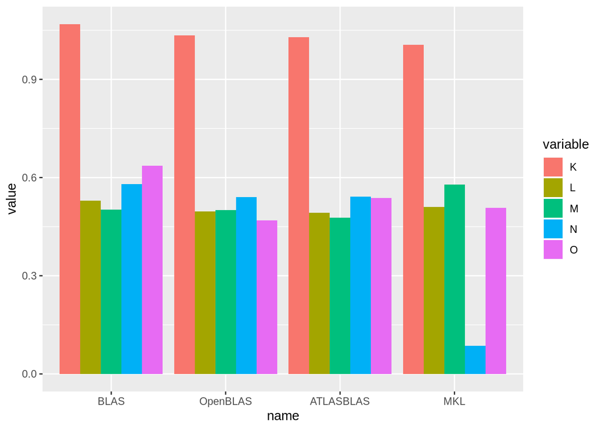

```
Trimmed geom. mean (2 extremes eliminated)           :      0.580     0.512   0.531     0.524
Total time for all 15 tests_________________________ :     60.932     11.222  9.563     19.158
Overall mean (sum of I, II and III trimmed means/3)_ :      1.834     0.642   0.566     1.031
```

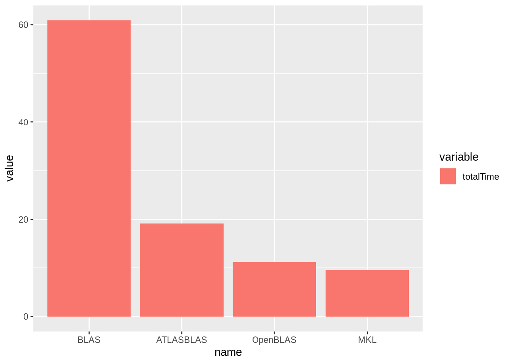

# Results

The Intel MKL (Microsoft R open)) are the clear winners for the used configuration. They are faster in most operations than OpenBLAS or ATLAS, It should be noted that while the MKL performs faster when running on Intel CPUs, OpenBLAS is typically faster on AMD CPUs.

## Paralell Development

OpenBLAS and the Intel MKL (and R Open) take advantage of multiple cores and multithreading, For some operations they will use multiple threads. This is great if your operation is serial in nature but it could interfer if you are trying to perform parallel operations (such as parallel foreach, parapply, etc.)

You should disable multi threading to avoid this. Fortunatley most of the performance from using these libraries comes from vectorized math not multi threading (see the following article for more info [Edge cases in using the Intel MKL and parallel programming](http://blog.revolutionanalytics.com/2015/10/edge-cases-in-using-the-intel-mkl-and-parallel-programming.html), while this is about MKL the same applies to openBLAS )

with openBLAS you can disable multihreading by using

```
openblas_set_num_threads(1)
```

on R open

```
setMKLthreads(1)
```

if you are using MKL then you should set environment variable MKL_NUM_THREADS ( you can set this in your .profile )

```
export MKL_NUM_THREADS=1
```

# Mac

Apple provides the Accelarate Framework which includes optimized BLAS libraries (veclib)

The following article [R: Use faster vecLib](https://gist.github.com/nicebread/6920c8287d7bffb03007)

```
## Enter these commands in the Mac OS Terminal

# use faster vecLib library
cd /Library/Frameworks/R.framework/Resources/lib
ln -sf  /System/Library/Frameworks/Accelerate.framework/Frameworks/vecLib.framework/Versions/Current/libBLAS.dylib libRblas.dylib

# return to default settings
cd /Library/Frameworks/R.framework/Resources/lib
ln -sf libRblas.0.dylib libRblas.dylib
```

sessionInfo() should return something similar to below if you are using the Accelerate Framework

```
Matrix products: default
BLAS: /System/Library/Frameworks/Accelerate.framework/Versions/A/Frameworks/vecLib.framework/Versions/A/libBLAS.dylib
LAPACK: /System/Library/Frameworks/Accelerate.framework/Versions/A/Frameworks/vecLib.framework/Versions/A/libLAPACK.dylib
```

I was unable to find benchmark results for this, but did find reports of performance similar to that of OpenBLAS.

The following article shows how to set up OpenBLAS on a Mac

https://luisspuerto.net/blog/2018/01/12/install-r-100-homebrew-edition-with-openblas-openmp-my-version/

# Windows

While it is possible to use alternative BLAS and LAPACK libraries on Windows, I found it easier just to use Microsoft R Open

# Resources

- BLAS http://www.netlib.org/blas/
- LAPACK http://www.netlib.org/lapack/
- OpenBLAS https://www.openblas.net/
- ATLAS http://math-atlas.sourceforge.net/
- Intel MKL https://software.intel.com/en-us/articles/free-ipsxe-tools-and-libraries
- Microsoft Open R (Formerly Revolution R Open) https://mran.microsoft.com/open
- GotoBLAS https://www.tacc.utexas.edu/research-development/tacc-software/gotoblas2
- Apple Accelerate https://developer.apple.com/documentation/accelerate
- [Amadahl’s Law](https://en.wikipedia.org/wiki/Amdahl%27s_law#Serial_programs)
- [gcbd: ‘GPU’/CPU Benchmarking in Debian-Based Systems](https://cran.r-project.org/web/packages/gcbd/index.html)
- [Faster BLAS in R](http://brettklamer.com/diversions/statistical/faster-blas-in-r/)